# Environment & postnatal depression descriptive statistics

Tim Cadman

31st May 2021

I’ve just put together some basic plots of each environmental exposure along with the postnatal depression outcome. I’ve split the environmental exposures into two time periods where available (i) pregnancy, (ii) birth - 12 months. You’ll see from the descriptives there is almost no difference between the two exposures for most variables.

I’ve also looked at the correlations between environmental variables.

# 1 Natural spaces

## 1.1 NDVI (300m buffer)

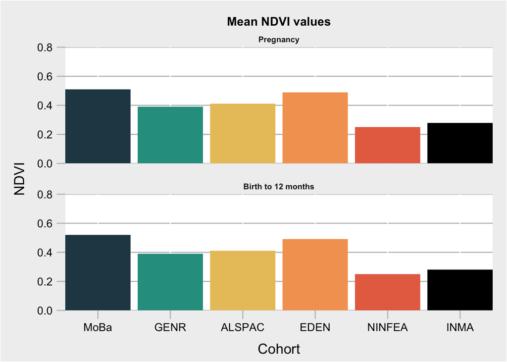

## 1.2 Distance to nearest green spaces > 5000m<sup>2</sup>

There’s definitely something wrong with GEN-R data. Here is the data for the other cohorts:

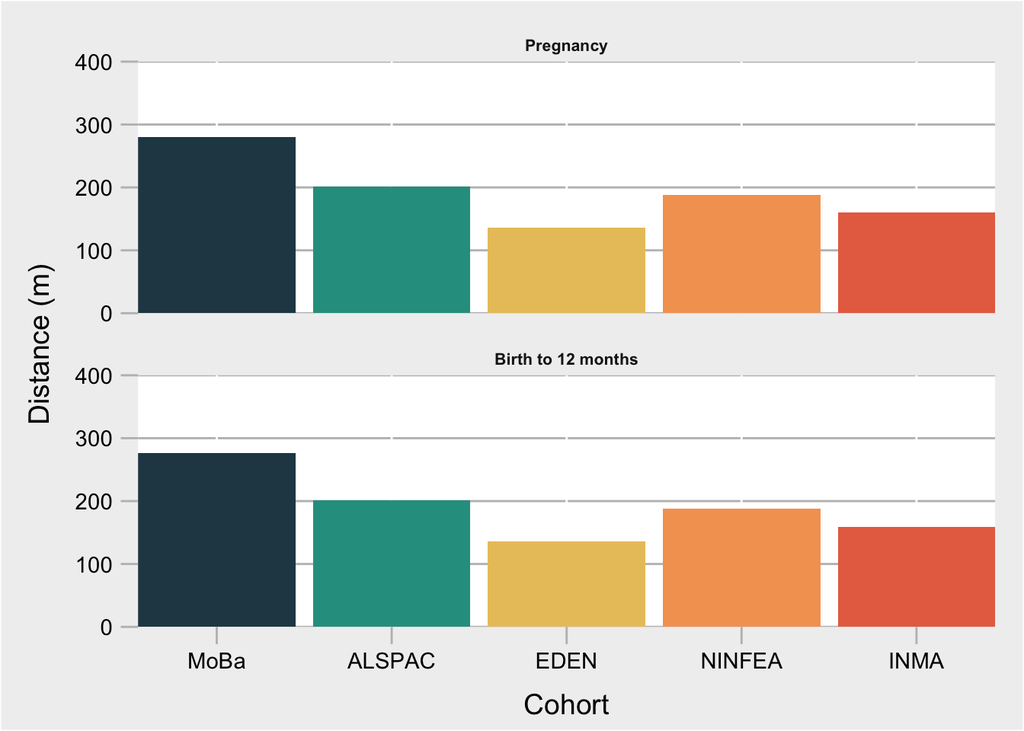

```r
desc_clean$continuous %>%
  filter(variable == "green_dist" & cohort == "genr") %>%
  select(cohort, time, mean, std.dev)
```

[output not shown]

## 1.3 Distance to nearest blue spaces > 5000m<sup>2</sup>

Again, something not right with GEN-R data

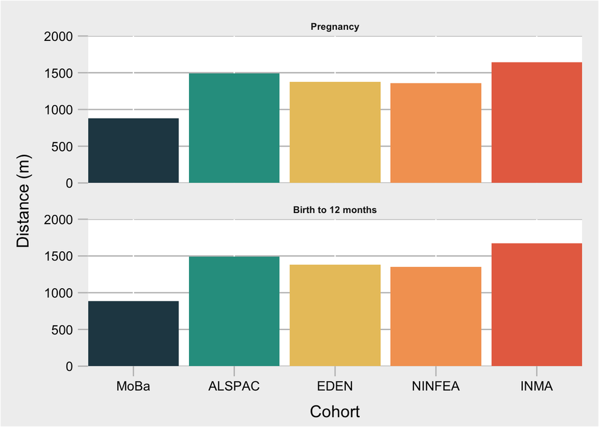

```r
desc_clean$continuous %>%
  filter(variable == "blue_dist" & cohort == "genr") %>%
  select(cohort, time, mean, std.dev)
```

[output not shown]

# 2 Air polution

## 2.1 Mean NO<sub>2</sub> in pregnancy

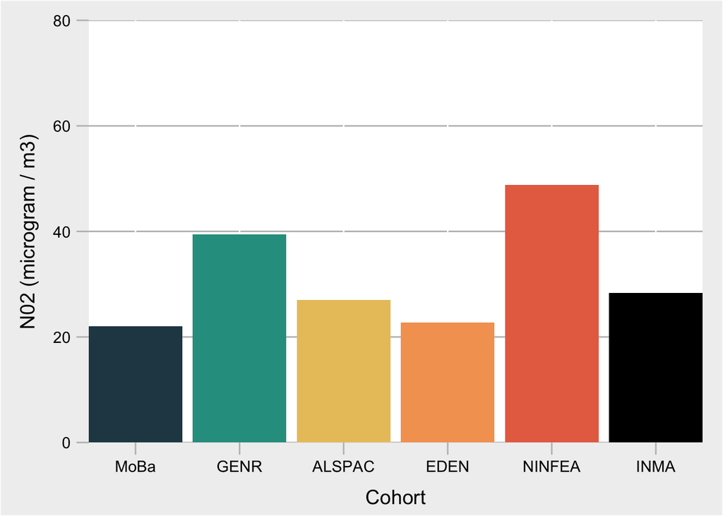

## 2.2 Mean PM<sub>2.5</sub> in pregnancy

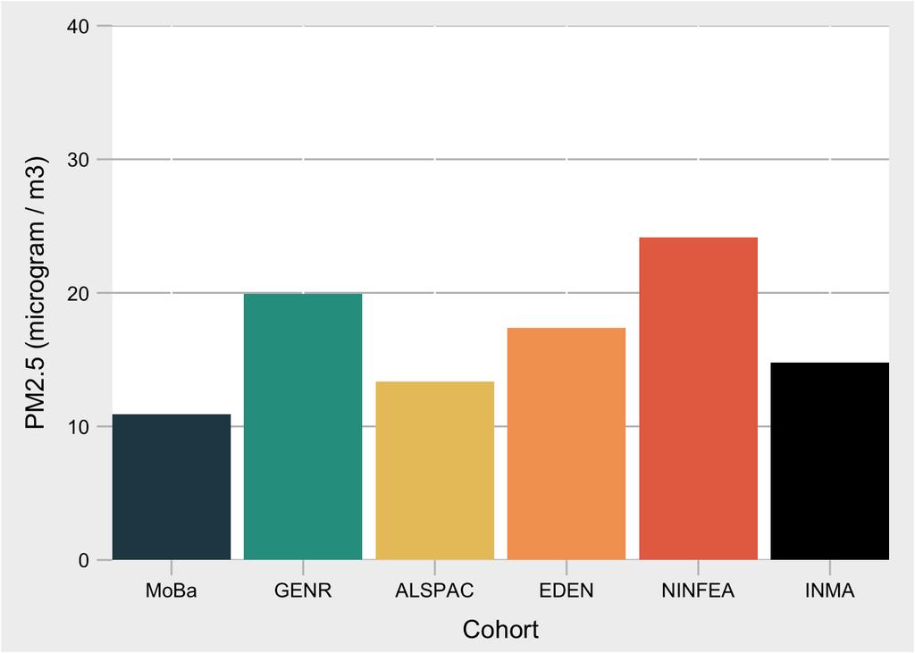

# 3 Mean day-evening-night traffic noise

This isn’t available for ALSPAC

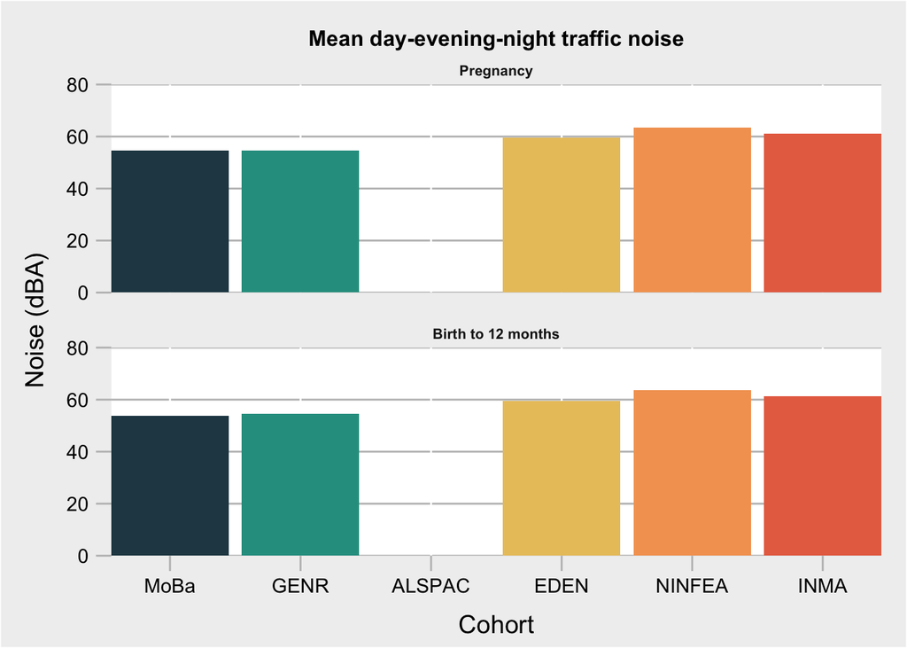

# 4 Land use

## 4.1 Mean buildling density

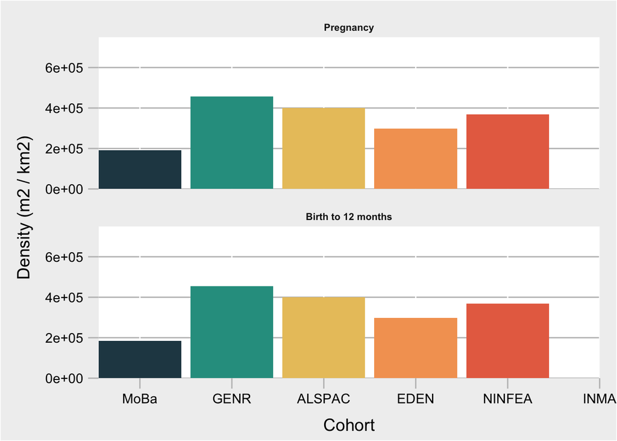

## 4.2 Percentage of urban green land use

Big difference between MoBa and other cohorts - does this look like an error?

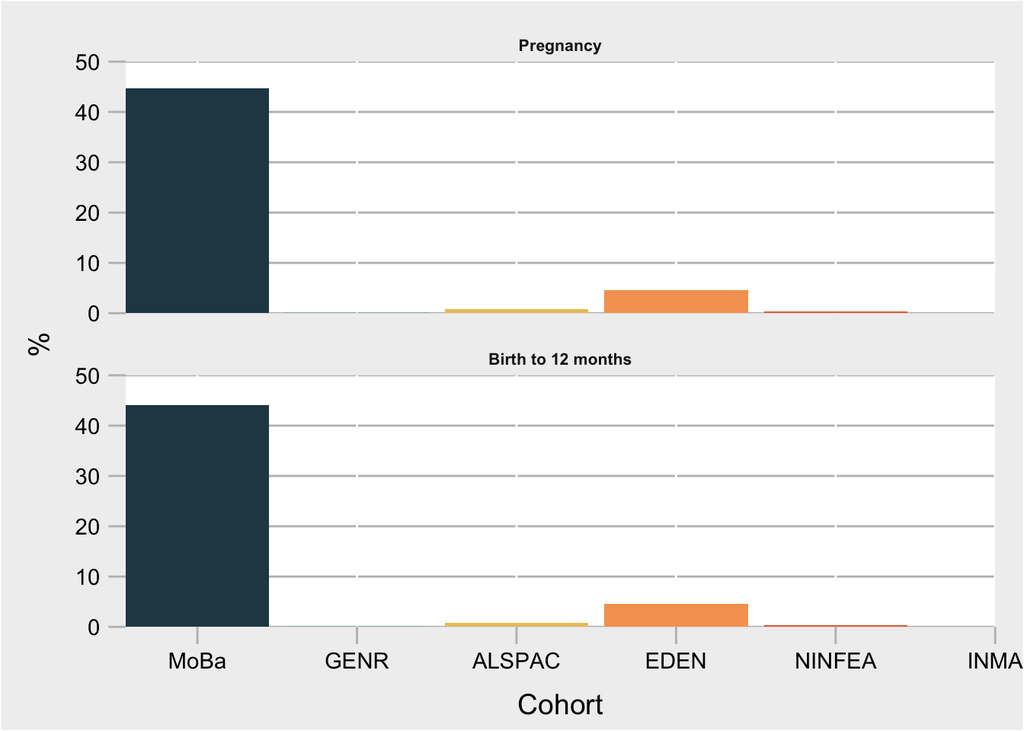

## 4.3 Percentage of forest land use

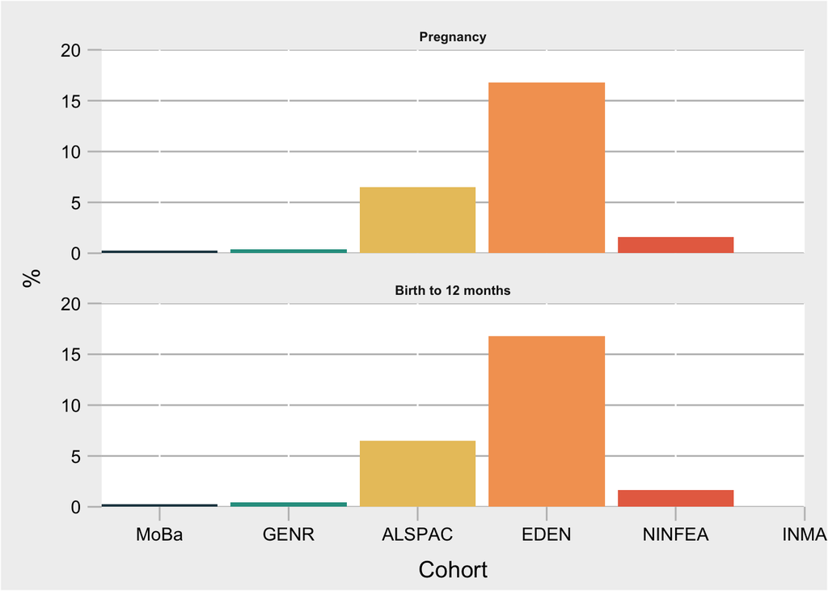

## 4.4 Walkability index

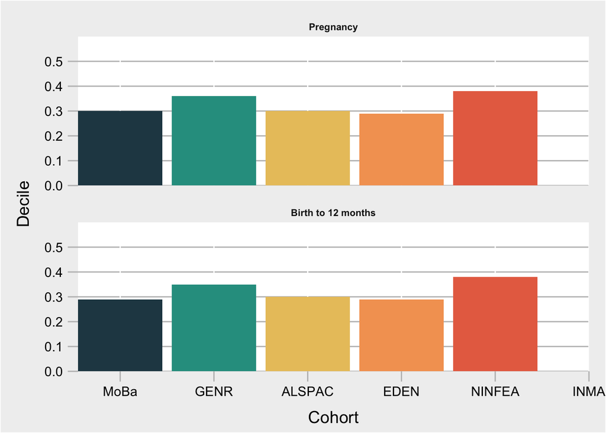

## 4.5 Land use (Shannon’s evenness index)

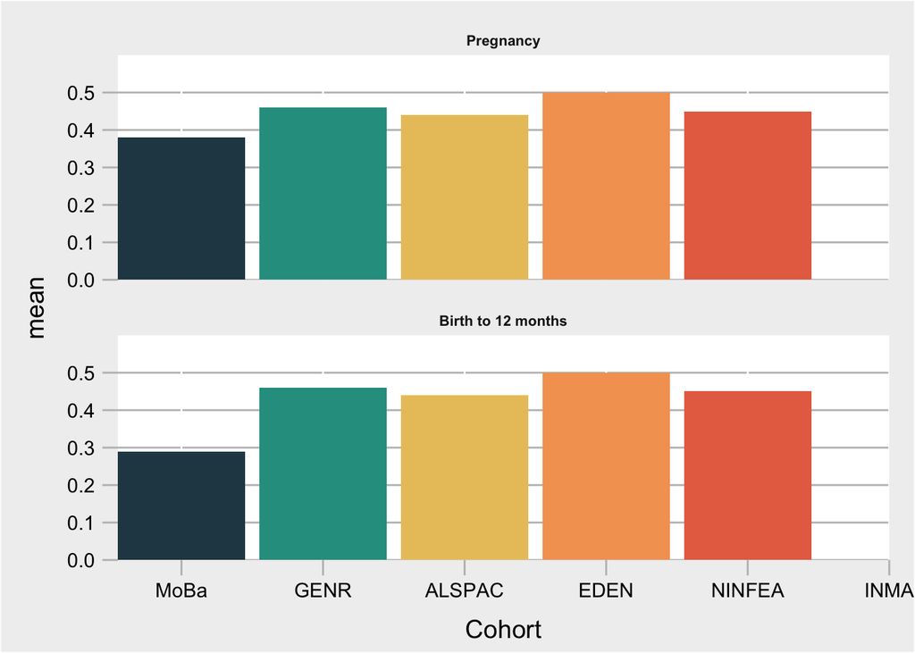

## 4.6 Facilities richness

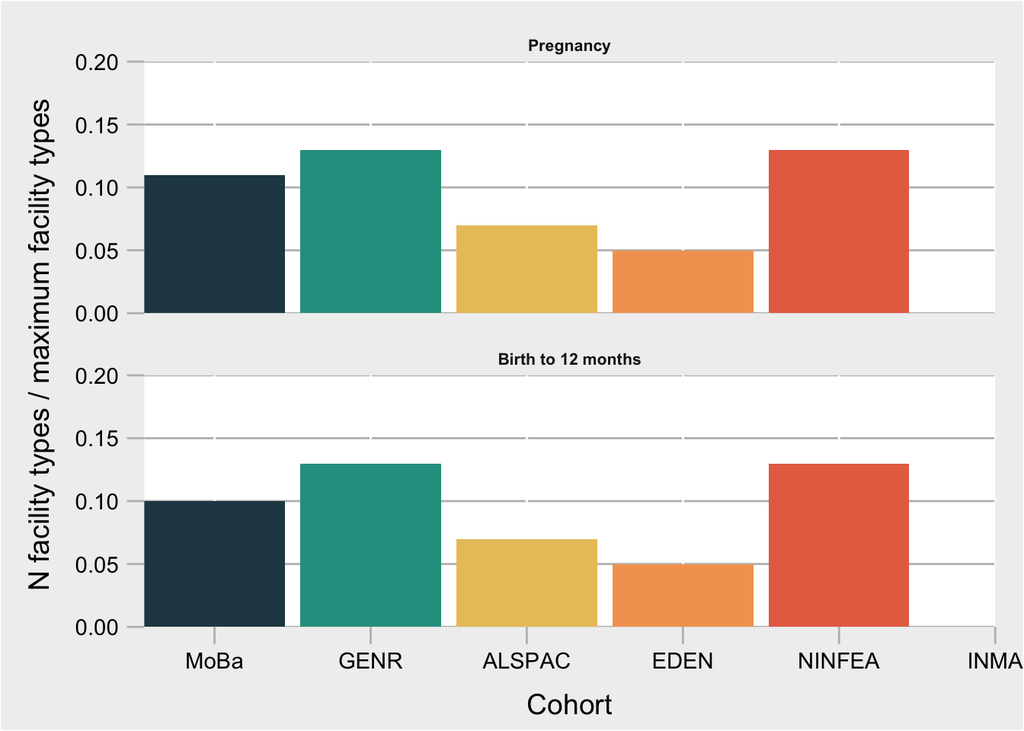

## 4.7 Facilities density

[figure not shown]

# 5 Correlations between exposures

To avoid overload I have just plotted correlations between the pregnancy exposures. It’s easy to add the exposures in the first year of life if you want to see them too.

## 5.1 ALSPAC

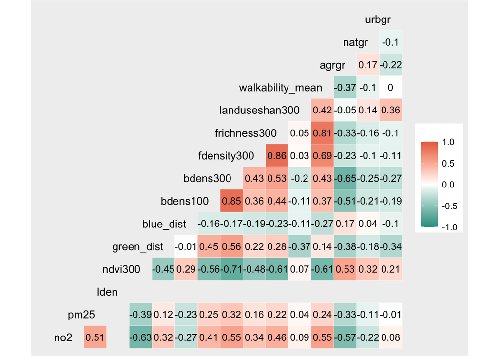

## 5.2 EDEN

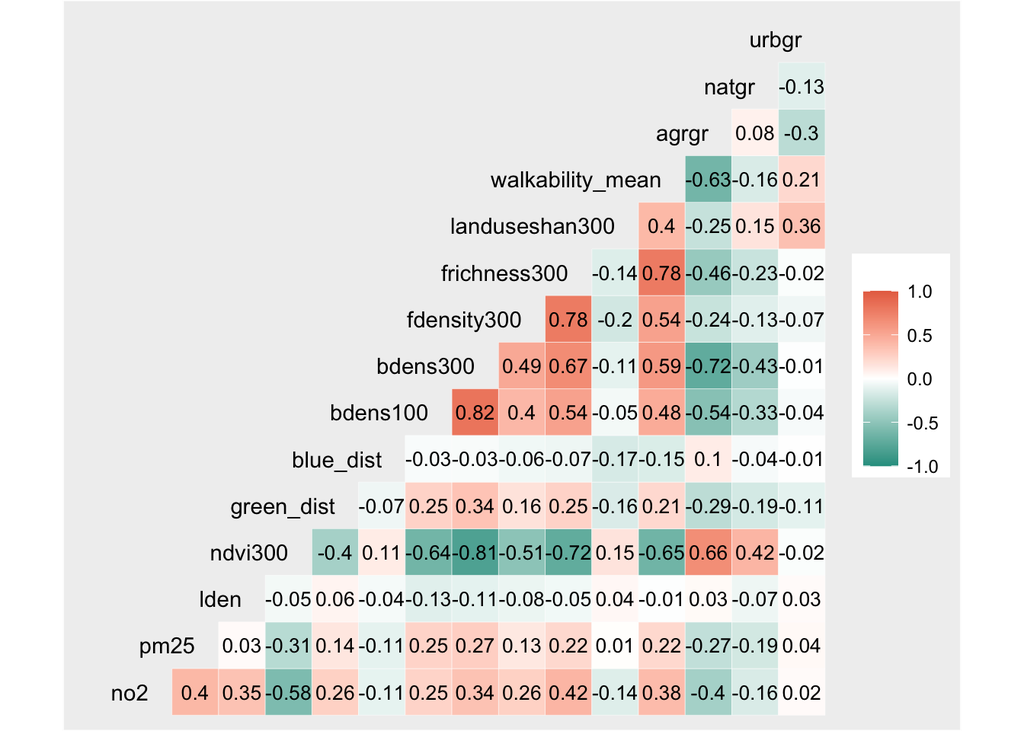

## 5.3 INMA

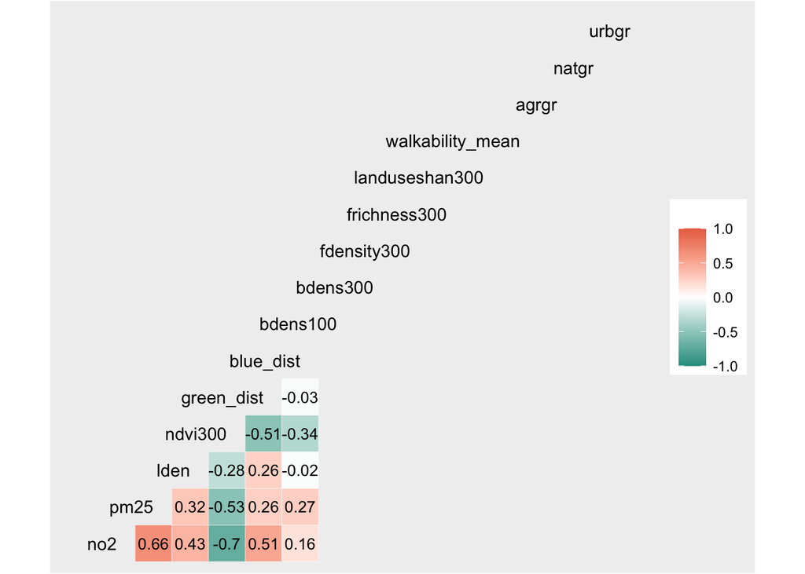

## 5.4 GEN-R

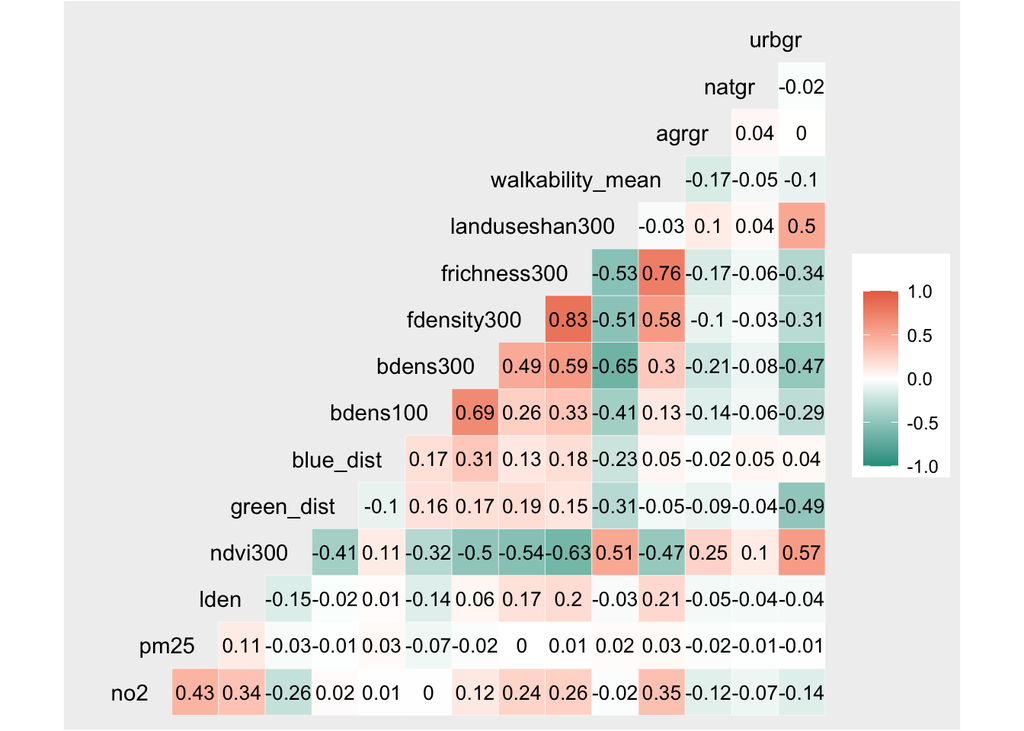

## 5.5 MoBa

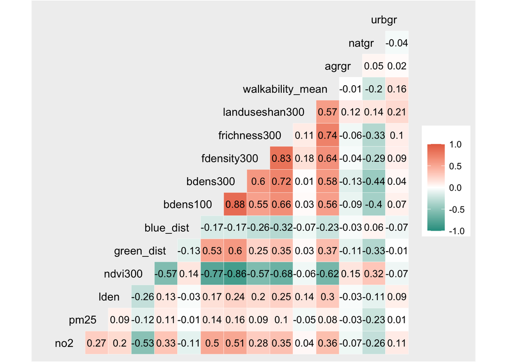

## 5.6 NINFEA

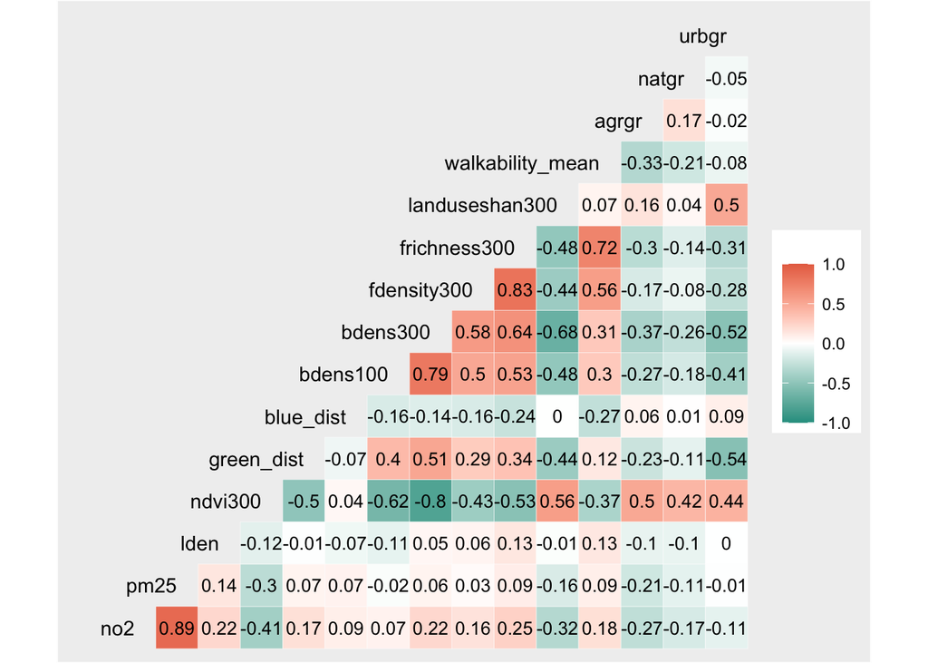

# 6 Postnatal depression

You can see something is clearly miscoded for MoBa - I will contact them about this. I am working with Luise to code the DNBC variables.

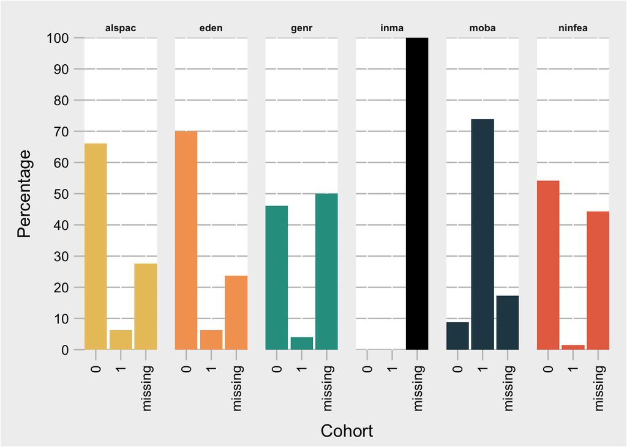